# kNN Analysis

# Overtraining: kNN with k = 1

Now, we reduce `k` to **1**, which means each prediction is based on the closest neighbor. This results in high variance and likely overfitting.

```r
knn_fit_1 <- knn3(y ~ ., data = mnist_27$train, k = 1)
y_hat_knn_1 <- predict(knn_fit_1, mnist_27$test, type = "class")
kNN_1_accuracy <- confusionMatrix(y_hat_knn_1, mnist_27$test$y)$overall["Accuracy"]
kNN_1_accuracy
```

```
## Accuracy
##     0.81
```

# Oversmoothing: kNN with k = 401

Next, we set `k` to **401**, meaning the decision boundary is based on a large number of neighbors, leading to oversmoothing.

```r
knn_fit_401 <- knn3(y ~ ., data = mnist_27$train, k = 401)
y_hat_knn_401 <- predict(knn_fit_401, mnist_27$test, type = "class")
kNN_401_accuracy <- confusionMatrix(y_hat_knn_401, mnist_27$test$y)$overall["Accuracy"]
kNN_401_accuracy
```

```
## Accuracy
##     0.76
```

While this approach prevents overfitting, it reduces model flexibility and may perform worse on complex patterns.

# Comparing Logistic Regression vs. kNN-401

Finally, we compare the decision boundaries of **logistic regression** and **kNN with k = 401** to see how they differ in classification behavior.

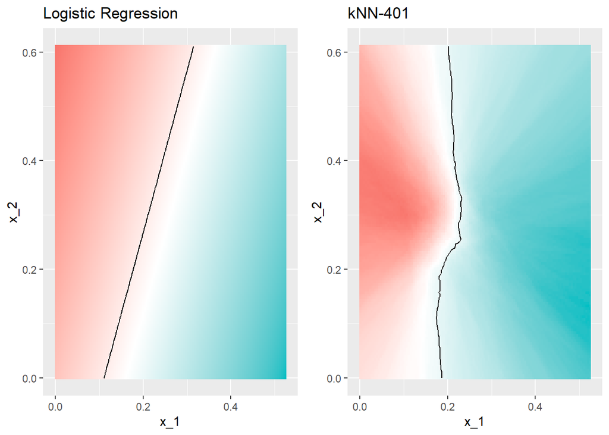

```r
fit_glm <- glm(y ~ x_1 + x_2, data=mnist_27$train, family="binomial")

p1 <- plot_cond_prob(predict(fit_glm, mnist_27$true_p)) + ggtitle("Logistic Regression")
p2 <- plot_cond_prob(predict(knn_fit_401, mnist_27$true_p)[,2]) + ggtitle("kNN-401")
grid.arrange(p1, p2, nrow=1)
```

This size of $k$ is so large that it does not permit enough flexibility